# s6_en

Research Seminar

Week 8: Seminar [October 26]

Sergi Martínez

smsoler@clio.uc3m.es | Office hours: Tuesdays 10:00–13:00 (by email)

## Upcoming dates

- October 30:
  - lecture on qualitative methods II: Ethnography
  - Observing and commenting on Empirical Strategy sections
  - 3-5 min presentation and feedback round
- November 2: submission via Aula Global

What do you need to submit?

- 1. Fix mistakes from the first submission (if any)
- (2) Description and justification of the case study, time period, geographical area, etc.
- **(3) description and justification of the qualitative design**
- 4. “brief” qualitative data collection and analysis

## Today

- Quant:
  - Regression
- Qualitative methods:
  - Recap
  - Process tracing

**Quantitative methods**

## From variance to regression: the logic

| Concept | What it asks | Logic | Formula |
| --- | --- | --- | --- |
| **Variance** | How distant/different are the values of one variable (w.r.t. the mean)? | Average squared distance of each value from its own mean | $Var(x) = \dfrac{\sum (x_i-\bar{x})^2}{n-1}$ |
| **Covariance** | Do these distances-from-the-mean move *together* in two variables? Positive, null, or negative association? | Average product of each pair’s distance from their own means | $Cov(x,y) = \dfrac{\sum (x_i-\bar{x})(y_i-\bar{y})}{n-1}$ |
| **Correlation** | Covariance depends on units (days, months, years), so how strong is the co-variation once we standardize it? Pos/null/neg, and how linear? | Covariance divided by the deviations (SDs) of each variable | $Cor(x,y) = \dfrac{Cov(x,y)}{sd(x)\,sd(y)}$ |
| **Regression** | If X moves by one unit, how much does Y move, on average? | Covariance standardized by the variance of X (not Y) | $\hat{\beta} = \dfrac{Cov(x,y)}{Var(x)}$ |

## From variance to regression: a detective story

Think of it as a detective story. Each concept answers a different question, using the same two clues:

1. **Variance** — how much do the obs of *one* variable wander on its own?
2. **Covariance** — do the *two* variables wander *together*? [the upper values wrt the mean of one variable coincide with the values wrt the mean of the other variable]
3. **Correlation** — how *reliable* is that pattern (on a universal scale)? [compare the cov by the variables’ SD]
4. **Regression** — if I see a new clue, what do I *predict*? [assess the cov by the values of X]

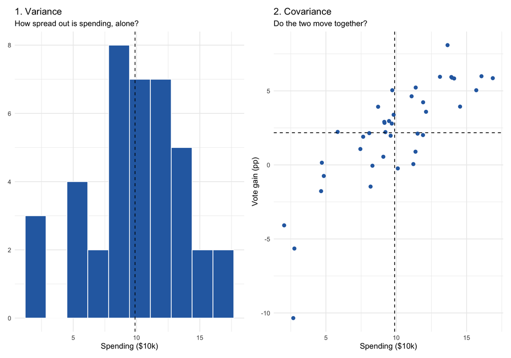

```r
library(tidyverse)
library(patchwork)

set.seed(42)
campaigns <- tibble(
  spending = rnorm(40, mean = 10, sd = 3),                       # $10,000s
  vote_gain = 0.8 * (spending - mean(spending)) +
    rnorm(40, mean = 2, sd = 2.2)                                 # pct. points
)

p_var <- ggplot(campaigns, aes(spending)) +
  geom_histogram(bins = 10, fill = "#2b6cb0", color = "white") +
  geom_vline(xintercept = mean(campaigns$spending), linetype = "dashed") +
  labs(title = "1. Variance", subtitle = "How spread out is spending, alone?",
       x = "Spending ($10k)", y = NULL) +
  theme_minimal(base_size = 11)

p_cov <- ggplot(campaigns, aes(spending, vote_gain)) +
  geom_point(size = 2, color = "#2b6cb0") +
  geom_vline(xintercept = mean(campaigns$spending), linetype = "dashed") +
  geom_hline(yintercept = mean(campaigns$vote_gain), linetype = "dashed") +
  labs(title = "2. Covariance", subtitle = "Do the two move together?",
       x = "Spending ($10k)", y = "Vote gain (pp)") +
  theme_minimal(base_size = 11)

(p_var | p_cov)
```

## Corr vs. reg

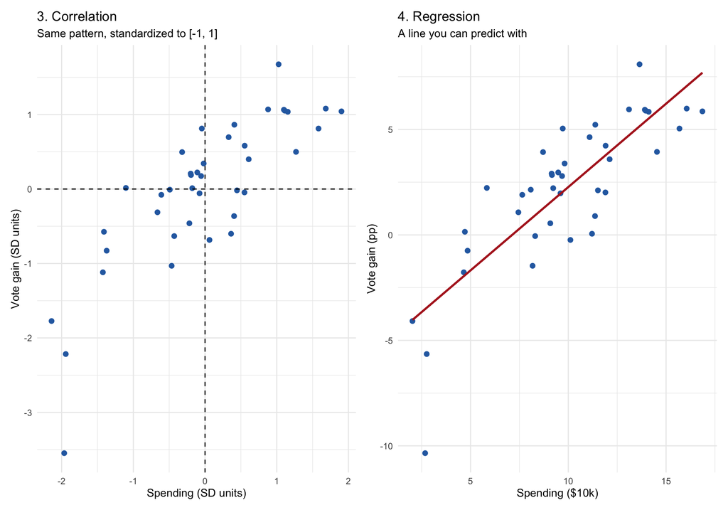

```r
p_cor <- ggplot(campaigns, aes(scale(spending), scale(vote_gain))) +
  geom_point(size = 2, color = "#2b6cb0") +
  geom_vline(xintercept = 0, linetype = "dashed") +
  geom_hline(yintercept = 0, linetype = "dashed") +
  labs(title = "3. Correlation", subtitle = "Same pattern, standardized to [-1, 1]",
       x = "Spending (SD units)", y = "Vote gain (SD units)") +
  theme_minimal(base_size = 11)

p_reg <- ggplot(campaigns, aes(spending, vote_gain)) +
  geom_point(size = 2, color = "#2b6cb0") +
  geom_smooth(method = "lm", se = FALSE, color = "firebrick") +
  labs(title = "4. Regression", subtitle = "A line you can predict with",
       x = "Spending ($10k)", y = "Vote gain (pp)") +
  theme_minimal(base_size = 11)

(p_cor | p_reg)
```

```r
c(variance   = var(campaigns$spending),
  covariance = cov(campaigns$spending, campaigns$vote_gain),
  correlation = cor(campaigns$spending, campaigns$vote_gain))
```

```
   variance  covariance correlation
 13.4480891  10.6285681   0.8210736
```

## Regression

Regardless the format, `spending` predicts `vote_gain` with a slope around 0.8

### 1. Base R: `summary(lm())`

```r
model <- lm(vote_gain ~ spending, data = campaigns)
summary(model)
```

```
Call:
lm(formula = vote_gain ~ spending, data = campaigns)

Residuals:
    Min      1Q  Median      3Q     Max
-6.8300 -1.4455  0.4714  1.2775  3.2518

Coefficients:
            Estimate Std. Error t value Pr(>|t|)
(Intercept) -5.63400    0.93804  -6.006 5.58e-07 ***
spending     0.79034    0.08913   8.867 8.64e-11 ***
---
Signif. codes:  0 '***' 0.001 '**' 0.01 '*' 0.05 '.' 0.1 ' ' 1

Residual standard error: 2.041 on 38 degrees of freedom
Multiple R-squared:  0.6742,    Adjusted R-squared:  0.6656
F-statistic: 78.62 on 1 and 38 DF,  p-value: 8.645e-11
```

### 2. `modelsummary()`: the quick, tidy version

```r
library(modelsummary)

modelsummary(list("Vote gain (pp)" = model),
             stars = TRUE,
             gof_map = c("nobs", "r.squared"))
```

|  | Vote gain (pp) |
| --- | --- |
| (Intercept) | -5.634*** |
|  | (0.938) |
| spending | 0.790*** |
|  | (0.089) |
| Num.Obs. | 40 |
| R2 | 0.674 |

+ p < 0.1, * p < 0.05, ** p < 0.01, *** p < 0.001

[figure not shown]

. . .

**Qualitative methods**

## Types of qualitative data

|  | People | Text |
| --- | --- | --- |
| Research context | Interviews Discussion/focus groups | Diaries and notes (requested) Open-ended questionnaires |
| “Real world” | Observational research (ethnography) | Discourse analysis Review of secondary sources (existing documents) |

Interviews and focus groups get people talking. Ethnography (we’ll see that next week) watches them live. The three underlined cells all work with **text**, not talk, but differ in who produced it and why

- Case study and process tracing combine these different qualitative sources to build a chronology of events and groups that reveals changes (effects). One focuses on the context, the other on the causal chain.

**Definitions and types**

## Interview

A research technique based on a professional, guided conversation with a specific purpose, aimed at gaining an in-depth understanding of the perspectives, motivations, values, ideologies and experiences of political or social actors

Obtaining information about

- What is actually going on in the process [meaning]
- How a process occurred [how X affected Y]
- Why a process occurred [what led to the decision, what was the sequence of events]
- The context in which the process occurred [actors, contextual details]

For this, we need a method: a list of questions or topics to discuss, and selection criteria for the people we are going to interview.

- The goal is **not** to observe patterns in a sample to extrapolate them to the population
- We want (**yes**) to understand why and how our phenomenon of interest occurred

## Example: CITREP

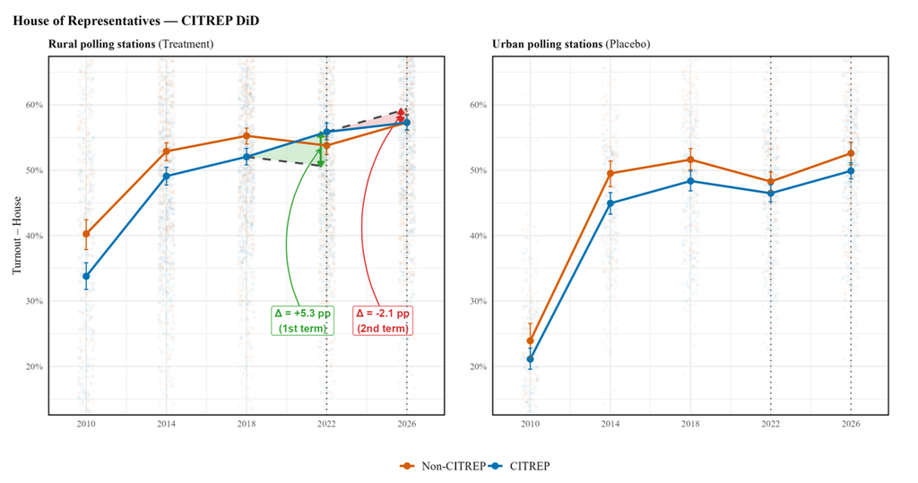

To answer why: Semi-structured interviews with local social and civic leaders, and MPs staff

## Example: CITREP (II)

[interactive chart not shown]

## Ilusión

[video not shown]

## Focus groups

A group interview in which a *moderator* encourages discussion among the interviewees.

- Advantage: the group dimension, which captures how people reason together, not just what each person thinks individually

[video not shown]

- About CITREP: This would have been great for identifying the construction of the narrative of disillusionment and distrust in the state

## Review of secondary sources (existing documents)

**Definition:** Systematic procedure for reviewing to develop empirical knowledge (Bowen, 2009, *Qualitative Research Journal*).

**Goal**: knowing what happened, who said what, what was decided, and when. Scott (*A Matter of Record*, 1990) proposes four criteria for judging a document’s usefulness: authenticity, credibility, representativeness and meaning

Examples:

- Posner (2004) draws on colonial administrative records and census documents to argue that it’s a matter of relative size within-countries what explains the same ethnic distinction (Chewa vs. Tumbuka) is politically salient in Zambia but not in Malawi
- Our paper in Colombia uses data from a previous survey to candidates, another to MP’s, a record of the FARC-EP–Government negotiations in Havana

Instances: other scholars’ datasets, government reports, NGO records, or court rulings

On its own, this approach does not standalone.

## Discourse analysis

If you’re asking “why was it written this way, and what does that make possible,” you’re doing discourse analysis

Language as a form of **social practice**, not a neutral window onto the world: texts both reflect and produce the categories, identities and power relations we study (Fairclough, *Discourse and Social Change*, 1992). Milliken (1999): In polsci, discourses are

- Structures of meaning that make some policies thinkable and others not
- Productive of the subjects and objects they describe
- And enact through concrete practices and sites of production (speeches, treaties, briefings)

Examples:

- Doty (1993, *International Studies Quarterly*) on how discourses sold the Philippines as “backward” and the US as naturally responsible for it

Discourse analysis asks **how** a text constructs meaning, sets the norm, and makes certain actions appear natural or necessary

## Example: A derradeira leición do mestre

[figure not shown]

Painted by Castelao in 1939 (re-printed in 1945) while exiled in Argentina

First time the painting returns to Spain: 2018

Feijoo (Xunta’s president at that time):

- “It is a highly significant work in his career and also a symbol for Galicia: for the hand that painted it, for its exceptional quality, and for the historical lesson it represents and the tribute it pays to teachers”
- “When Castelao painted this work in 1945, the Galicia he wanted could only be dreamed of. Fortunately, since then, the Galician people have managed to achieve the self-government we enjoy today. To a large extent, we are the Galicia he dreamed of.”

## Diaries and notes

**Definition.** Diaries are “documents created by individuals who maintain a regular, personal and contemporaneous log/record” of their own activity, thoughts or interactions

- **Solicited** diaries are commissioned by the researcher for the study (a daily log of conversations, activities, or tasks)
- **Unsolicited** diaries, letters or notes exist independently and are later analyzed as a found text
- Bolger, Davis and Rafaeli (2003, *Annual Review of Psychology*) argue diaries capture **process**, not just a retrospective summary, reducing recall bias for routine or mundane behavior that an interview would smooth over
- Wrote a paper about the aerial strikes during the North Campaign in Biscay: checked the diaries to know the pilots’ perceptions of accuracy, the weather, etc.

**Tip**

Compare/validate what people *say* they do (interviews, diaries, surveys) with what ethnographers observe them actually doing [Pager et al.] vs. Diaries are closer to behavior than a retrospective interview, but they are still a verbal account, not a behavioral record

## Case study

Gerring (2004): An intensive study of a single unit for the purpose of understanding a larger class of (similar) units. A unit connotes a spatially bounded phenomenon—e.g., a nation-state, revolution, political party, election, or person—observed at a single point in time or over some delimited period of time.

Sources/Data: Every qual [interviews, focus groups, secondary sources, etc.]

Then, every paper we’re reading for the course (remember the list of publications at APSR) is a case study?

**Yes, but** here we want to focus on a the qualitative method:

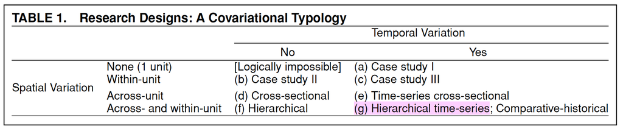

- Remember Lapuente et al.?

## Kantola and Lombardo’s paper

*Kantola, J., & Lombardo, E. (2019). Populism and feminist politics: The cases of Finland and Spain. European Journal of Political Research, 58(4), 1108-1128.*

Case studies to understand how populist parties are linked to feminism - Cases: Finns far right and Podemos (far left). Is the case selection well justified?

Institutional analyses - Formal. Are they similar or comparable? - Informal. Are they similar or comparable?

Materials and sources

- Interviews with women in the parties
- Secondary sources: Manifestos, communication, policy proposal

[interactive chart not shown]

## Process tracing

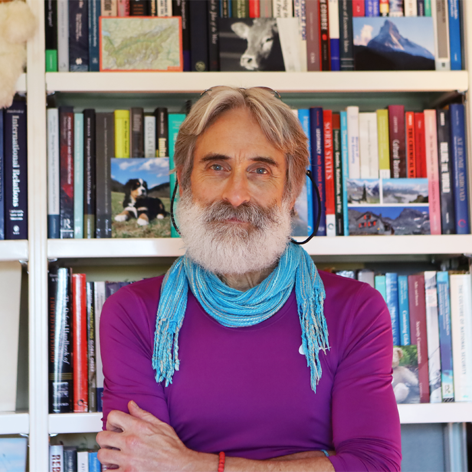

[figure not shown]

**What is it?**

- An analytical tool for generating causal and descriptive inferences from diagnosing pieces of evidence that form the temporal sequence of events/phenomena.
- It is used to test hypotheses (also to generate them, but we won’t discuss that here). Specifying hypotheses is fundamental for selecting cases and interpreting the evidence we find.

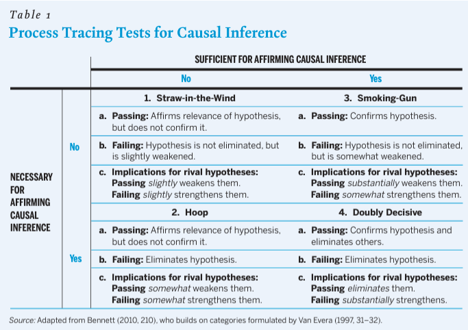

**It is used to observe the observable implications of causal mechanisms**

1. Carefully describe each stage
2. Analyze the relationship between each stage

**How?**

1. Primary sources: interviews, focus groups, external observation (vs. participant observation)
2. Secondary sources: state documentation, memoirs, biographies, newspapers. Note that this information can be quantitative.

## Example: Crims, Elena Jubany

[video not shown]

## Example: Pavone et al.

Pavone, T., & Stiansen, Ø. (2022). The shadow effect of courts: Judicial review and the politics of preemptive reform. American Political Science Review, 116(1), 322-336.

Shadow effect of courts: Just their existence may trigger independent offices to push for policy reforms

- Case of Norway and EU law
- Policy: denial of social benefits to tourists and people who went back to their countries of origin
- Data: internal (confidential) communication (letters and emails) between EFTA–Norwegian Govt. (NAV), with far-right people–NIC (independent agency)

[interactive chart not shown]

## Example: Tannerwald

Tannenwald, N. (1999). The Nuclear Taboo: The United States and the Normative Basis of Nuclear Non-Use. International Organization, 53(3), 433–468.

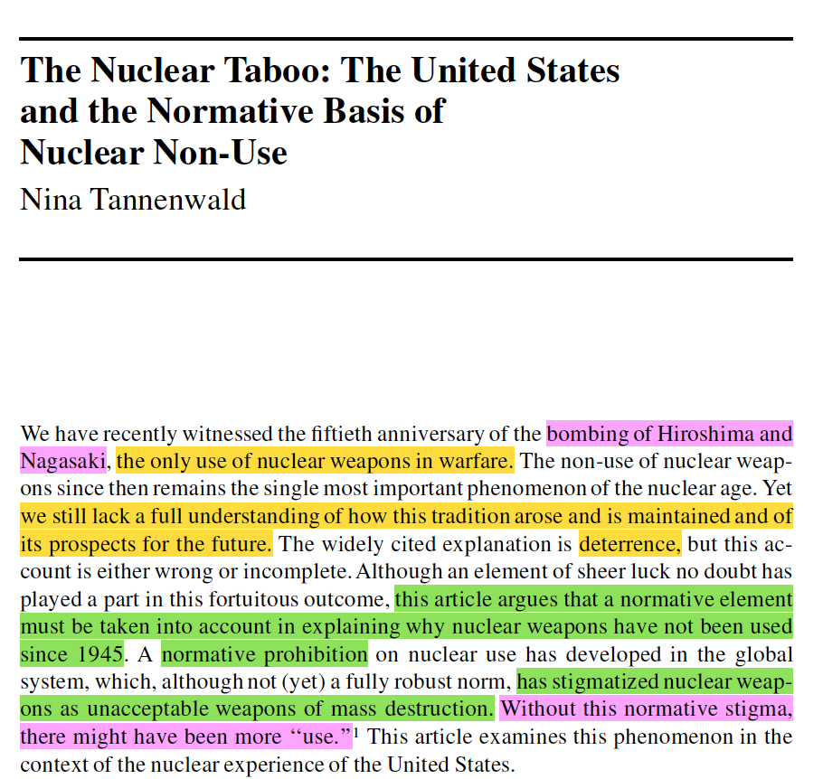

- Argument/hypothesis: the use of nuclear weapons in WWII created a taboo on nuclear policy.
- Evidence:
1. There was an anti-nuclear reaction after WWII, and how considerable it was (who it affected). It traces *reactions based on fear and horror* in documents and biographies.
2. How the elements of that reaction came together to create a silence/taboo around it.
- The author relies mainly on documentation from secondary sources.

**Tip**

While I think evidence based on this methodology would be insufficient on its own to establish a causal relationship, I think it complements evidence via *Difference-in-Differences* very well

## Another example: Victims of democratization

- Argument: Including armed groups in democratic processes without securing peace may raise killings of politicians and trigger revenge dynamics
- Case: The Colombian civil war and FARC-EP–Unión Patriótica
- Quant findings: $\Delta$ Killings of traditional policitians in t-1 -> $\Delta$ Killings of non-traditional policitians in t, if this municipality had shifted control
- Qual Hypo:
  - If we are right: we should observe that assassinations were directed (ordered) for political reasons across ideological and political parties
  - If we are right: we should observe this directionality of violence is justified by previous assassinations
- Qual evidence: process tracing using memoires, confessions to police and judiciary, and interviews

[interactive chart not shown]

## Now it’s time for office hours

## See you on Friday! Any question at smsoler@clio.uc3m.es

[figure not shown]

Research Seminar